# Data wrangling

Reading and wrangling data with the {tidyverse}

Dr Massimiliano Canzi

## Today

By the end of this class you will be able to

- explain what the `tidyverse` is and what tidy data looks like
- read and write `.csv` files with `{readr}`
- use the core `{dplyr}` verbs: `select()`, `filter()`, `arrange()`, `rename()`, `mutate()`
- summarise data by group with `summarise()` and `count()`
- chain everything together with the pipe `|>`

# The tidyverse

*“R is not a language driven by the purity of its philosophy; R is a language designed to get shit done.”*

Hadley Wickham (Chief Scientist at Posit, formerly RStudio)

## Tidyverse

A collection of R packages that share the same design, grammar and data structures.

- A dialect of R: everything you know from base R still works
- Functions are verbs named after what they do
- The data always comes first, so functions can be chained
- Output is (almost) always a data frame, so the next step knows what to expect
- Together with Quarto / R Markdown: reproducible analyses

## Base R vs tidyverse

Same question: *mean body mass of Gentoo penguins, in kg*

Base R

```r
gentoo <- penguins[penguins$species == "Gentoo", ]
mean(gentoo$body_mass_g / 1000, na.rm = TRUE)
```

`tidyverse`

```r
penguins |>
  filter(species == "Gentoo") |>
  summarise(mass_kg = mean(body_mass_g / 1000, na.rm = TRUE))
```

Both give the same answer; the tidyverse version reads more like a sentence.

## The core tidyverse

`library(tidyverse)` loads nine packages:

| Package | What it does |
| --- | --- |
| `readr` | read and write rectangular data (.csv, .tsv) |
| `tibble` | a modern data frame |
| `dplyr` | manipulate data: filter, select, mutate, summarise |
| `tidyr` | reshape data (wide to long and back) |
| `ggplot2` | plots |
| `stringr` | work with text |
| `forcats` | work with factors (categorical variables) |
| `lubridate` | work with dates and times |
| `purrr` | apply functions repeatedly (iteration) |

## The typical workflow

Almost every analysis goes through the same steps, and each has its own tools:

| Import | Tidy | Transform | Visualise | Model | Communicate |
| --- | --- | --- | --- | --- | --- |
| `{readr}` | `{tidyr}` | `{dplyr}` | `{ggplot2}` | `lm()` and friends | Quarto, R Markdown |
| today | today | today | next class | lectures 4–13 | your assignment |

The steps are not a straight line: plotting often sends you back to transform, and a model often sends you back to plot.

## Tidy data

A data set is tidy when

1. each variable is a column
2. each observation is a row
3. each value is a cell

`Frequency` is a variable. Where is it?

Untidy (wide)

| participant | rt_high | rt_low |
| --- | --- | --- |
| P01 | 580 | 642 |
| P02 | 611 | 690 |

Tidy (long)

| participant | frequency | rt |
| --- | --- | --- |
| P01 | high | 580 |
| P01 | low | 642 |
| P02 | high | 611 |
| P02 | low | 690 |

## Discussion

You record 20 speakers reading the same 30 words, and measure F1, F2 and the duration of each vowel.

- What is one row in your tidy data set? Which columns do you need?
- Where would information about the speakers, such as age or dialect, go?

## From wide to long

`pivot_longer()` from `{tidyr}` turns the wide table into a tidy one:

```r
wide <- tibble(participant = c("P01", "P02"), rt_high = c(580, 611), rt_low = c(642, 690))
wide |>
  pivot_longer(c(rt_high, rt_low), names_to = "frequency", values_to = "rt",
               names_prefix = "rt_")
```

```
# A tibble: 4 × 3
  participant frequency    rt
  <chr>       <chr>     <dbl>
1 P01         high        580
2 P01         low         642
3 P02         high        611
# ℹ 1 more row
```

`pivot_wider()` goes the other way, which is sometimes handy for tables in a paper.

## Tibbles

A `tibble` is a data frame with nicer defaults.

```r
penguins
```

```
# A tibble: 344 × 8
  species island    bill_length_mm bill_depth_mm flipper_length_mm
  <fct>   <fct>              <dbl>         <dbl>             <int>
1 Adelie  Torgersen           39.1          18.7               181
2 Adelie  Torgersen           39.5          17.4               186
3 Adelie  Torgersen           40.3          18                 195
# ℹ 341 more rows
# ℹ 3 more variables: body_mass_g <int>, sex <fct>, year <int>
```

- Prints only the first rows and the columns that fit
- Shows the type of each column: `<fct>`, `<dbl>`, `<int>`, `<chr>`

## `glimpse()`

A transposed overview: one line per column.

```r
glimpse(penguins)
```

```
Rows: 344
Columns: 8
$ species           <fct> Adelie, Adelie, Adelie, Adelie, Adelie, Ad…
$ island            <fct> Torgersen, Torgersen, Torgersen, Torgersen…
$ bill_length_mm    <dbl> 39.1, 39.5, 40.3, NA, 36.7, 39.3, 38.9, 39…
$ bill_depth_mm     <dbl> 18.7, 17.4, 18.0, NA, 19.3, 20.6, 17.8, 19…
$ flipper_length_mm <int> 181, 186, 195, NA, 193, 190, 181, 195, 193…
$ body_mass_g       <int> 3750, 3800, 3250, NA, 3450, 3650, 3625, 46…
$ sex               <fct> male, female, female, NA, female, male, fe…
$ year              <int> 2007, 2007, 2007, 2007, 2007, 2007, 2007, …
```

# Example data

`Did you know:` the 344 rows of the `penguins` data are real birds: adult Adélie, Chinstrap and Gentoo penguins nesting near Palmer Station, Antarctica, measured by Dr Kristen Gorman and the Palmer Station LTER team from 2007 to 2009.

*Sources: Gorman, Williams & Fraser (2014), PLoS ONE; palmerpenguins documentation*

## The `penguins` data

344 penguins, 3 species, 3 islands in the Palmer Archipelago (Antarctica).

```r
install.packages("palmerpenguins")
library(palmerpenguins)
```

## `penguins` in base R

`Heads up!` Since R 4.5.0, base R also ships a `penguins` data set, but with shorter column names:

| `{palmerpenguins}` | base R ≥ 4.5.0 |
| --- | --- |
| `bill_length_mm` | `bill_len` |
| `bill_depth_mm` | `bill_dep` |
| `flipper_length_mm` | `flipper_len` |
| `body_mass_g` | `body_mass` |

In this course we always load `{palmerpenguins}` first. If you get `object 'bill_length_mm' not found`, you forgot!

# `{readr}`

## Reading and writing files

| Function | For files that look like |
| --- | --- |
| `read_csv()` | `word,rt` with commas between values |
| `read_tsv()` | values separated by tabs |
| `read_csv2()` | `word;rt` with semicolons and decimal commas, as in German Excel exports |
| `read_delim()` | any other separator |
| `write_csv()` | saves a data frame as a .csv file |

```r
library(readr)
data <- read_csv("data/my_file.csv")

# ... do things with data ...

write_csv(data, "data/my_file_clean.csv")
```

## What `read_csv()` tells you

```r
rt <- read_csv(example_file)
```

[output not shown]

- Rows and columns read
- The type it guessed for each column
- If a guess is wrong, set it yourself:

```r
rt <- read_csv("data/rt.csv",
               col_types = cols(participant = col_factor()))
```

## `read_csv()` vs `read.csv()`

|  | `read_csv()` | `read.csv()` |
| --- | --- | --- |
| Package | `{readr}` | base R |
| Returns | tibble | data.frame |
| Speed | fast | slower on large files |
| Reports column types | yes | no |

Use `read_csv()` (with an `_`) in this course.

# `{dplyr}`

`Did you know:` Adélie penguins take their name from Adélie Land in Antarctica, which the French explorer Jules Dumont d’Urville named after his wife, Adèle, in 1840.

*Source: Australian Antarctic Division*

## The grammar of `{dplyr}`

Every `{dplyr}` verb works the same way:

1. The first argument is a data frame
2. The other arguments say what to do, using column names without quotes
3. The output is a new data frame

## Six verbs

| Verb | Works on | Does |
| --- | --- | --- |
| `select()` | columns | keep or drop columns |
| `rename()` | columns | change column names |
| `mutate()` | columns | create or change columns |
| `filter()` | rows | keep rows that match a condition |
| `arrange()` | rows | sort rows |
| `summarise()` | groups | collapse many rows into one |

## The verb never changes your data

```r
filter(penguins, species == "Gentoo")
```

```
# A tibble: 124 × 8
  species island bill_length_mm bill_depth_mm flipper_length_mm
  <fct>   <fct>           <dbl>         <dbl>             <int>
1 Gentoo  Biscoe           46.1          13.2               211
2 Gentoo  Biscoe           50            16.3               230
3 Gentoo  Biscoe           48.7          14.1               210
# ℹ 121 more rows
# ℹ 3 more variables: body_mass_g <int>, sex <fct>, year <int>
```

```r
nrow(penguins)
```

```
[1] 344
```

Nothing happened to `penguins`! To keep the result, assign it:

```r
gentoo <- filter(penguins, species == "Gentoo")
nrow(gentoo)
```

```
[1] 124
```

# Columns

## `select()`

Keep the columns you name:

```r
select(penguins, species, bill_length_mm)
```

```
# A tibble: 344 × 2
  species bill_length_mm
  <fct>            <dbl>
1 Adelie            39.1
2 Adelie            39.5
3 Adelie            40.3
# ℹ 341 more rows
```

Drop a column with `-`

```r
select(penguins, -year)
```

## `select()` helpers

Select by name pattern or type instead of typing every name:

```r
select(penguins, species:bill_depth_mm)   # a range of columns
select(penguins, starts_with("bill"))     # names starting with "bill"
select(penguins, ends_with("_mm"))        # names ending with "_mm"
select(penguins, contains("length"))      # names containing "length"
select(penguins, where(is.numeric))       # all numeric columns
select(penguins, sex, everything())       # move sex to the front
```

```r
select(penguins, ends_with("_mm"))
```

```
# A tibble: 344 × 3
  bill_length_mm bill_depth_mm flipper_length_mm
           <dbl>         <dbl>             <int>
1           39.1          18.7               181
2           39.5          17.4               186
3           40.3          18                 195
# ℹ 341 more rows
```

## `select()` by position

Also possible, but fragile:

```r
select(penguins, 1, 3, 5)
select(penguins, 1:4)
select(penguins, -(1:5))
```

If the column order changes (new data export, a colleague’s file), your code silently selects the wrong columns. Prefer names.

## `rename()`

`new_name = old_name`

```r
rename(penguins, Type = species)
```

```
# A tibble: 344 × 8
  Type   island    bill_length_mm bill_depth_mm flipper_length_mm
  <fct>  <fct>              <dbl>         <dbl>             <int>
1 Adelie Torgersen           39.1          18.7               181
2 Adelie Torgersen           39.5          17.4               186
3 Adelie Torgersen           40.3          18                 195
# ℹ 341 more rows
# ℹ 3 more variables: body_mass_g <int>, sex <fct>, year <int>
```

`select()` can rename too, but drops everything you do not name:

```r
select(penguins, Type = species, bill_length_mm)
```

```
# A tibble: 344 × 2
  Type   bill_length_mm
  <fct>           <dbl>
1 Adelie           39.1
2 Adelie           39.5
3 Adelie           40.3
# ℹ 341 more rows
```

## `mutate()`

Create new columns, or overwrite existing ones:

```r
penguins_2 <- mutate(penguins,
                     body_mass_kg = body_mass_g / 1000,
                     bill_ratio   = bill_length_mm / bill_depth_mm)
select(penguins_2, species, body_mass_kg, bill_ratio)
```

```
# A tibble: 344 × 3
  species body_mass_kg bill_ratio
  <fct>          <dbl>      <dbl>
1 Adelie          3.75       2.09
2 Adelie          3.8        2.27
3 Adelie          3.25       2.24
# ℹ 341 more rows
```

New columns are added at the end. You can use a column you just created in the same `mutate()`.

## `mutate()` with conditions

`if_else()` for two outcomes

```r
mutate(penguins, size = if_else(body_mass_g > 4500, "large", "small"))
```

`case_when()` for more than two

```r
penguins_2 <- mutate(penguins,
  size = case_when(
    body_mass_g < 3500 ~ "small",
    body_mass_g < 4500 ~ "medium",
    body_mass_g >= 4500 ~ "large"
  )
)
count(penguins_2, size)
```

```
# A tibble: 4 × 2
  size       n
  <chr>  <int>
1 large    118
2 medium   153
3 small     71
# ℹ 1 more row
```

Conditions are checked in order. Rows matching none of them get `NA`.

## `mutate()` on many columns: `across()`

`mutate_if()` and `mutate_all()` are superseded: they still work, but are no longer developed. Use `across()`:

```r
# old
mutate_if(penguins, is.factor, as.character)

# new
mutate(penguins, across(where(is.factor), as.character))
```

`across(columns, function)`: *apply this function to these columns*

```r
mutate(penguins, across(ends_with("_mm"), \(x) x / 10))  # mm to cm
```

`\(x) x / 10` is a short way to write a small function: *take x, divide it by 10*.

# Rows

## `filter()`

Keep the rows where a condition is `TRUE`:

```r
filter(penguins, species == "Gentoo")
```

```
# A tibble: 124 × 8
  species island bill_length_mm bill_depth_mm flipper_length_mm
  <fct>   <fct>           <dbl>         <dbl>             <int>
1 Gentoo  Biscoe           46.1          13.2               211
2 Gentoo  Biscoe           50            16.3               230
3 Gentoo  Biscoe           48.7          14.1               210
# ℹ 121 more rows
# ℹ 3 more variables: body_mass_g <int>, sex <fct>, year <int>
```

## Comparison operators

| Operator | Meaning | Example |
| --- | --- | --- |
| `==` | equal to | `species == "Gentoo"` |
| `!=` | not equal to | `species != "Gentoo"` |
| `>`, `>=` | greater than (or equal) | `body_mass_g > 4000` |
| `<`, `<=` | less than (or equal) | `year <= 2008` |
| `%in%` | one of | `island %in% c("Biscoe", "Dream")` |
| `is.na()` | missing | `is.na(sex)` |

`=` assigns, `==` compares. `filter(penguins, species = "Gentoo")` gives an error.

## Combining conditions

`,` or `&`: both must be true (AND)

```r
filter(penguins, species == "Gentoo", body_mass_g > 5000)
filter(penguins, species == "Gentoo" & body_mass_g > 5000)
```

`|`: at least one must be true (OR)

```r
filter(penguins, species == "Gentoo" | species == "Chinstrap")
```

`%in%` is shorter when matching several values of one column

```r
unique(filter(penguins, species %in% c("Gentoo", "Chinstrap"))$species)
```

```
[1] Gentoo    Chinstrap
Levels: Adelie Chinstrap Gentoo
```

## `filter()` and missing values

`filter()` drops rows where the condition is `NA`.

```r
nrow(penguins)
```

```
[1] 344
```

```r
sum(is.na(penguins$sex))
```

```
[1] 11
```

```r
nrow(filter(penguins, sex == "female"))
```

```
[1] 165
```

```r
nrow(filter(penguins, sex != "female"))
```

```
[1] 168
```

`165 + 168 = 333`, not 344! The 11 penguins with unknown `sex` are dropped by both.

## Discussion

In a listening experiment, some participants did not respond on a few trials, so those cells are `NA`.

- Should these trials be removed, kept as `NA`, or counted as wrong answers?
- Does your answer depend on why the response is missing?

## `filter_out()` (new in `{dplyr}` 1.2.0)

Say which rows to drop. Rows with `NA` are kept.

```r
nrow(filter_out(penguins, sex == "female"))
```

```
[1] 179
```

Rule of thumb:

- `filter()` when you know what to keep
- `filter_out()` when you know what to drop

Requires `{dplyr}` ≥ 1.2.0. Check with `packageVersion("dplyr")`.

## `arrange()`

Sort rows, smallest first

```r
arrange(penguins, body_mass_g)
```

```
# A tibble: 344 × 8
  species   island bill_length_mm bill_depth_mm flipper_length_mm
  <fct>     <fct>           <dbl>         <dbl>             <int>
1 Chinstrap Dream            46.9          16.6               192
2 Adelie    Biscoe           36.5          16.6               181
3 Adelie    Biscoe           36.4          17.1               184
# ℹ 341 more rows
# ℹ 3 more variables: body_mass_g <int>, sex <fct>, year <int>
```

Largest first with `desc()`; sort by several columns in turn

```r
arrange(penguins, desc(body_mass_g))
arrange(penguins, species, desc(body_mass_g))
```

# Groups

`Did you know:` chinstrap penguins sleep in microsleeps: more than 10,000 a day, about 4 seconds each, which add up to about 11 hours of sleep.

*Source: Libourel et al. (2023), Science*

## `summarise()`

Collapse many rows into one

```r
summarise(penguins,
          mean_mass = mean(body_mass_g, na.rm = TRUE),
          sd_mass   = sd(body_mass_g, na.rm = TRUE),
          n         = n())
```

```
# A tibble: 1 × 3
  mean_mass sd_mass     n
      <dbl>   <dbl> <int>
1     4202.    802.   344
```

`na.rm = TRUE`: ignore missing values. Without it, one `NA` makes the whole result `NA`.

## `group_by()` + `summarise()`

One row per group

```r
penguins_grouped <- group_by(penguins, species)
summarise(penguins_grouped,
          mean_mass = mean(body_mass_g, na.rm = TRUE),
          n         = n())
```

```
# A tibble: 3 × 3
  species   mean_mass     n
  <fct>         <dbl> <int>
1 Adelie        3701.   152
2 Chinstrap     3733.    68
3 Gentoo        5076.   124
```

`group_by()` changes nothing you can see. It tells the next verb to work group by group.

## `.by`: grouping for one step

Same result, without a separate `group_by()`:

```r
summarise(penguins,
          mean_mass = mean(body_mass_g, na.rm = TRUE),
          n         = n(),
          .by       = c(species, sex))
```

```
# A tibble: 8 × 4
  species sex    mean_mass     n
  <fct>   <fct>      <dbl> <int>
1 Adelie  male       4043.    73
2 Adelie  female     3369.    73
3 Adelie  <NA>       3540      6
# ℹ 5 more rows
```

`.by` groups for this verb only, so you never forget to `ungroup()`. It works in `summarise()`, `mutate()`, `filter()` and `slice()`.

## `count()`

A shortcut for counting rows per group

```r
count(penguins, species, island)
```

```
# A tibble: 5 × 3
  species island        n
  <fct>   <fct>     <int>
1 Adelie  Biscoe       44
2 Adelie  Dream        56
3 Adelie  Torgersen    52
# ℹ 2 more rows
```

Same counts as `summarise(penguins, n = n(), .by = c(species, island))`, but `count()` also sorts the rows by group.

# The pipe

`Did you know:` gentoo penguins are the fastest swimming birds: they reach about 36 km/h in short bursts, close to Usain Bolt’s average speed in his 100 m world record.

*Source: Guinness World Records*

## The problem

Three steps, three intermediate objects:

```r
penguins_2 <- filter(penguins, species == "Gentoo" | species == "Chinstrap")
penguins_3 <- mutate(penguins_2, bill_length_cm = bill_length_mm / 10)
penguins_4 <- select(penguins_3, species, bill_length_cm)
```

Or nested, read from the inside out:

```r
penguins_4 <- select(
  mutate(
    filter(penguins, species == "Gentoo" | species == "Chinstrap"),
    bill_length_cm = bill_length_mm / 10),
  species, bill_length_cm)
```

## The pipe `|>`

`x |> f(y)` is the same as `f(x, y)`

- Takes the result on the left, passes it as the first argument of the function on the right
- Read it aloud as then. There is no need to repeat the object at every step

```r
penguins_2 <- penguins |>
  filter(species == "Gentoo" | species == "Chinstrap") |>
  mutate(bill_length_cm = bill_length_mm / 10) |>
  select(species, bill_length_cm)
penguins_2
```

```
# A tibble: 192 × 2
  species bill_length_cm
  <fct>            <dbl>
1 Gentoo            4.61
2 Gentoo            5
3 Gentoo            4.87
# ℹ 189 more rows
```

## Reading a pipe aloud

| Code | Read it as |
| --- | --- |
| `penguins_2 <- penguins \\|>` | Take `penguins`, then |
| `filter(species == "Gentoo" \\| species == "Chinstrap") \\|>` | keep only Gentoo and Chinstrap penguins, then |
| `mutate(bill_length_cm = bill_length_mm / 10) \\|>` | add bill length in cm, then |
| `select(species, bill_length_cm)` | keep only these two columns. |

Store the result as `penguins_2`. If you cannot read a pipe aloud like this, it is probably doing too much at once.

## `PRO TIP!` Save to the right

```r
penguins |>
  filter(species == "Gentoo" | species == "Chinstrap") |>
  mutate(bill_length_cm = bill_length_mm / 10) |>
  select(species, bill_length_cm) -> penguins_2
```

Same output as the previous slide. The code now reads top to bottom in the order things happen.

## `|>` vs `%>%`

You will see two pipes in the wild:

- `%>%` from `{magrittr}`, loaded with the tidyverse (since 2014)
- `|>` built into R itself (since R 4.1.0)

For everything in this course they are interchangeable. We use `|>`: it works without loading any package.

Keyboard shortcut: `Ctrl/Cmd + Shift + M`

To make it insert `|>`: *Tools > Global Options > Code > Use native pipe operator*

## From wrangling to plotting

The output of a pipe can go straight into `{ggplot2}`

```r
penguins |>
  filter_out(is.na(sex)) |>
  ggplot(aes(x = flipper_length_mm, y = body_mass_g, colour = species)) +
  geom_point(size = 2, alpha = 0.8) +
  labs(x = "Flipper length (mm)", y = "Body mass (g)", colour = NULL)
```

Note: `{ggplot2}` layers are added with `+`, not `|>`. More next class.

## From wrangling to plotting

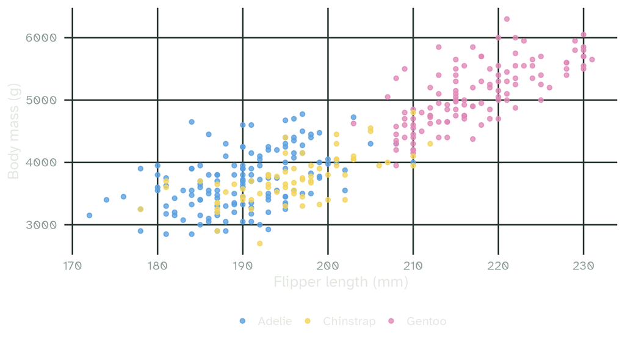

# Common errors

## Common errors

| You wrote | Problem |
| --- | --- |
| `filter(df, species = "Gentoo")` | `=` instead of `==` |
| `filter(df, species == Gentoo)` | text values need `"quotes"` |
| `select(df, Species)` | names are case sensitive |
| `filter(df, ...)` and nothing changes | result not assigned with `<-` |
| `mean(body_mass_g)` gives `NA` | missing values: add `na.rm = TRUE` |
| `object 'bill_length_mm' not found` | forgot `library(palmerpenguins)` |
| `could not find function "filter_out"` | `{dplyr}` older than 1.2.0 |

## Summary

- `{readr}`: `read_csv()`, `write_csv()`
- Columns: `select()`, `rename()`, `mutate()`, `across()`
- Rows: `filter()`, `filter_out()`, `arrange()`
- Groups: `summarise()`, `count()`, `group_by()` or `.by`
- Chain with `|>`, read as then
- Always assign the result if you want to keep it

## Slides and code

[figure not shown]

These slides

mcanzi.de/ws26_statistics/02_data_wrangling.html

Code, data and all lectures

github.com/mcanzi/ws26_statistics